# Study 1 – Network Discernment

Conversational Linguistic Features Predict Social Network Learning

Helen Schmidt

2022-10-04

Set up themes and notebook-wide settings.

```r
# set up themes and notebook-wide settings
my.alpha = .2
colors <- c("#2185c5ff","#ff9715ff","#f20253ff","#7ecefdff","#1c3aa9ff")
se <- function(x) sqrt(var(x)/length(x))  #function to calculate SE
```

Set global working directory.

Read in data.

```r
data <- read.csv("./Paper-Analysis/data/dat_survivor.csv")
# name first column relative trial order
names(data)[1] <- "RelativeTrialOrder"
# name second column raw trial order
names(data)[2] <- "RawTrialOrder"

capFirst <- function(s) {paste(toupper(substring(s, 1, 1)), substring(s, 2), sep = "")}
data$Target <- capFirst(data$Target)
data$LeftPersonImg <- capFirst(data$LeftPersonImg)
data$RightPersonImg <- capFirst(data$RightPersonImg)
data$choice <- capFirst(data$choice)
data[data == "Shiiann"] = "ShiiAnn"
# name rename clips
names(data)[8] <- "ClipNumber"

# print number of observations
numObs <- nrow(data)
print(paste0("Number of observations = ", numObs, sep = ""))
```

```
## [1] "Number of observations = 34735"
```

# 1. Reaction times across conditions

Analyze reaction time across the three conditions (rt ~ block type + (1|PID)) to see if the relational judgments are made slower than the win judgments.

```r
# rename RT column
names(data)[9] <- "RT"
# summarize mean RTs for each participant in each block type
reactions <- data %>%
  group_by(condType, PID) %>%
  summarize(meanRT = mean(RT))

# print mean RTs for each condition
average.RTs <- reactions %>%
  group_by(condType) %>%
  summarize(meanRTs = mean(meanRT))

print(average.RTs)
```

```
## # A tibble: 3 × 2
##   condType meanRTs
##   <chr>      <dbl>
## 1 Friend      2.57
## 2 Rival       2.60
## 3 Win         2.11
```

```r
# whole data
data$condType <- as.factor(data$condType)
data <- within(data, condType <- relevel(condType, ref = "Win"))

# run multilevel model
modelDW <- lmer(RT ~ condType + (1|PID), data = data)
summary(modelDW)
```

```
## Linear mixed model fit by REML. t-tests use Satterthwaite's method [
## lmerModLmerTest]
## Formula: RT ~ condType + (1 | PID)
##    Data: data
##
## REML criterion at convergence: 95435.5
##
## Scaled residuals:
##        Min         1Q     Median         3Q        Max
## -2.7903972 -0.7508008 -0.1159439  0.6643480  3.8969777
##
## Random effects:
##  Groups   Name        Variance  Std.Dev.
##  PID      (Intercept) 0.1191533 0.3451860
##  Residual             0.9066455 0.9521793
## Number of obs: 34735, groups:  PID, 57
##
## Fixed effects:
##                    Estimate   Std. Error           df  t value   Pr(>|t|)
## (Intercept)    2.104837e+00 4.656054e-02 5.873904e+01 45.20645 < 2.22e-16 ***
## condTypeFriend 4.699966e-01 1.250027e-02 3.467615e+04 37.59892 < 2.22e-16 ***
## condTypeRival  4.968750e-01 1.249777e-02 3.467620e+04 39.75711 < 2.22e-16 ***
## ---
## Signif. codes:  0 '***' 0.001 '**' 0.01 '*' 0.05 '.' 0.1 ' ' 1
##
## Correlation of Fixed Effects:
##             (Intr) cndTyF
## condTypFrnd -0.133
## condTypeRvl -0.133  0.496
```

```r
confint(modelDW)
```

```
##                       2.5 %       97.5 %
## .sig01         0.2869979189 0.4168441015
## .sigma         0.9451093870 0.9592821930
## (Intercept)    2.0128926318 2.1967857692
## condTypeFriend 0.4454965864 0.4944966827
## condTypeRival  0.4723797173 0.5213699990
```

```r
# also run null comparing random effects to RTs
modelRand <- lmer(RT ~ (1|PID), data = data)
anova(modelDW, modelRand)
```

|  | npar | AIC | BIC | logLik | deviance | Chisq | Df | Pr(>Chisq) |
| --- | --- | --- | --- | --- | --- | --- | --- | --- |
| modelRand | 3 | 97372.10234 | 97397.46885 | -48683.05117 | 97366.10234 | NA | NA | NA |
| modelDW | 5 | 95427.00382 | 95469.28133 | -47708.50191 | 95417.00382 | 1949.098526 | 2 | 0 |

## Plot

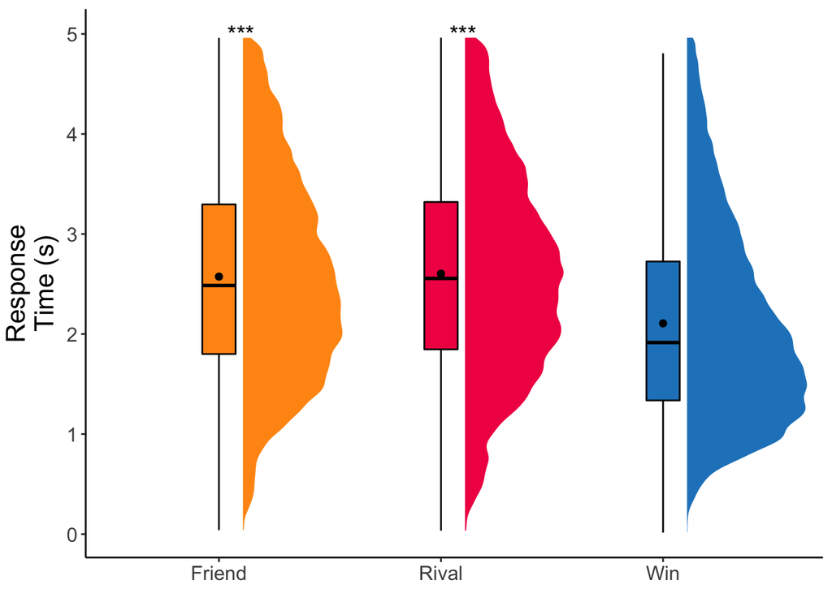

```r
RTs <- summarySE(data, measurevar = "RT", groupvars = "condType")

plot.colors <- c(colors[2], colors[3], colors[1])

# make condType a character for plotting
data$condType <- as.character(data$condType)

# violin plot
ggplot(data, aes(x = condType, y = RT, color = condType, fill = condType)) +
  stat_halfeye(adjust = 0.5, width = 0.6, .width = 0,
               justification = -0.2) +
  geom_boxplot(width = 0.15, outlier.shape = NA, color = "black") +
  # fill with my selected colors
  scale_fill_manual(values = plot.colors) +
  scale_color_manual(values = plot.colors) +
  # add point for mean of each valence category
  geom_point(data = average.RTs,
             aes(x = condType, y = meanRTs), color = "black", shape = 16,
             size = 2) +
  # add significance stars
  ggplot2::annotate("text", x = 1.1, y = 5, label = "***", size = 5) +
  ggplot2::annotate("text", x = 2.1, y = 5, label = "***", size = 5) +
  xlab(NULL) +
  ylab("Response\nTime (s)") +
  theme_classic() +
  theme(legend.position = "none",
        panel.background = element_blank(),
        axis.title.x = element_text(vjust = -0.4, size = 16),
        axis.title.y = element_text(vjust = 1.5, size = 16),
        axis.text = element_text(size = 12),
        legend.text = element_text(size = 10),
        legend.title = element_text(size = 12))
```

```r
RT.condition <- last_plot()
```

## Re-reference model

```r
# whole data
data$condType <- as.factor(data$condType)
data <- within(data, condType <- relevel(condType, ref = "Friend"))

# run multilevel model
model <- lmer(RT ~ condType + (1|PID), data = data)
summary(model)
```

```
## Linear mixed model fit by REML. t-tests use Satterthwaite's method [
## lmerModLmerTest]
## Formula: RT ~ condType + (1 | PID)
##    Data: data
##
## REML criterion at convergence: 95435.5
##
## Scaled residuals:
##        Min         1Q     Median         3Q        Max
## -2.7903972 -0.7508008 -0.1159439  0.6643480  3.8969777
##
## Random effects:
##  Groups   Name        Variance  Std.Dev.
##  PID      (Intercept) 0.1191533 0.3451860
##  Residual             0.9066455 0.9521793
## Number of obs: 34735, groups:  PID, 57
##
## Fixed effects:
##                    Estimate    Std. Error            df   t value Pr(>|t|)
## (Intercept)    2.574833e+00  4.657490e-02  5.881154e+01  55.28371  < 2e-16 ***
## condTypeRival  2.687837e-02  1.255073e-02  3.467627e+04   2.14158 0.032234 *
## condTypeWin   -4.699966e-01  1.250027e-02  3.467615e+04 -37.59892  < 2e-16 ***
## ---
## Signif. codes:  0 '***' 0.001 '**' 0.01 '*' 0.05 '.' 0.1 ' ' 1
##
## Correlation of Fixed Effects:
##             (Intr) cndTyR
## condTypeRvl -0.135
## condTypeWin -0.135  0.502
```

```r
confint(model)
```

```
##                         2.5 %        97.5 %
## .sig01         0.286997920421  0.4168441023
## .sigma         0.945109387000  0.9592821936
## (Intercept)    2.482862052720  2.6668093039
## condTypeRival  0.002279264115  0.0514771830
## condTypeWin   -0.494496682722 -0.4454965864
```

## Standardized Betas

```r
# z-score RTs
data$RT.z <- as.numeric(scale(data$RT))
# summarize mean RTs for each participant in each block type
reactions <- data %>%
  group_by(condType, PID) %>%
  summarize(meanRT.z = mean(RT.z))

# print mean RTs for each condition
average.RTs <- reactions %>%
  group_by(condType) %>%
  summarize(meanRTs.z = mean(meanRT.z))

print(average.RTs)
```

```
## # A tibble: 3 × 2
##   condType meanRTs.z
##   <fct>        <dbl>
## 1 Friend       0.147
## 2 Rival        0.176
## 3 Win         -0.303
```

```r
# whole data
data$condType <- as.factor(data$condType)
data <- within(data, condType <- relevel(condType, ref = "Win"))

# run multilevel model
modelDW <- lmer(RT.z ~ condType + (1|PID), data = data)
summary(modelDW)
```

```
## Linear mixed model fit by REML. t-tests use Satterthwaite's method [
## lmerModLmerTest]
## Formula: RT.z ~ condType + (1 | PID)
##    Data: data
##
## REML criterion at convergence: 92919.2
##
## Scaled residuals:
##        Min         1Q     Median         3Q        Max
## -2.7903972 -0.7508008 -0.1159439  0.6643480  3.8969777
##
## Random effects:
##  Groups   Name        Variance  Std.Dev.
##  PID      (Intercept) 0.1108263 0.3329059
##  Residual             0.8432847 0.9183053
## Number of obs: 34735, groups:  PID, 57
##
## Fixed effects:
##                     Estimate    Std. Error            df  t value   Pr(>|t|)
## (Intercept)    -3.052577e-01  4.490414e-02  5.873903e+01 -6.79799 6.0551e-09
## condTypeFriend  4.532764e-01  1.205557e-02  3.467615e+04 37.59892 < 2.22e-16
## condTypeRival   4.791985e-01  1.205315e-02  3.467620e+04 39.75711 < 2.22e-16
##
## (Intercept)    ***
## condTypeFriend ***
## condTypeRival  ***
## ---
## Signif. codes:  0 '***' 0.001 '**' 0.01 '*' 0.05 '.' 0.1 ' ' 1
##
## Correlation of Fixed Effects:
##             (Intr) cndTyF
## condTypFrnd -0.133
## condTypeRvl -0.133  0.496
```

```r
confint(modelDW)
```

```
##                        2.5 %        97.5 %
## .sig01          0.2767879074  0.4020147833
## .sigma          0.9114869163  0.9251555223
## (Intercept)    -0.3939309797 -0.2165798804
## condTypeFriend  0.4296479490  0.4769048564
## condTypeRival   0.4555747067  0.5028221486
```

```r
# also run null comparing random effects to RTs
modelRand <- lmer(RT.z ~ (1|PID), data = data)
anova(modelDW, modelRand)
```

|  | npar | AIC | BIC | logLik | deviance | Chisq | Df | Pr(>Chisq) |
| --- | --- | --- | --- | --- | --- | --- | --- | --- |
| modelRand | 3 | 94855.66037 | 94881.02688 | -47424.83018 | 94849.66037 | NA | NA | NA |
| modelDW | 5 | 92910.56184 | 92952.83936 | -46450.28092 | 92900.56184 | 1949.098526 | 2 | 0 |

```r
# whole data
data$condType <- as.factor(data$condType)
data <- within(data, condType <- relevel(condType, ref = "Friend"))

# re-reference
model <- lmer(RT.z ~ condType + (1|PID), data = data)
summary(model)
```

```
## Linear mixed model fit by REML. t-tests use Satterthwaite's method [
## lmerModLmerTest]
## Formula: RT.z ~ condType + (1 | PID)
##    Data: data
##
## REML criterion at convergence: 92919.2
##
## Scaled residuals:
##        Min         1Q     Median         3Q        Max
## -2.7903972 -0.7508008 -0.1159439  0.6643480  3.8969777
##
## Random effects:
##  Groups   Name        Variance  Std.Dev.
##  PID      (Intercept) 0.1108263 0.3329059
##  Residual             0.8432847 0.9183053
## Number of obs: 34735, groups:  PID, 57
##
## Fixed effects:
##                    Estimate    Std. Error            df   t value   Pr(>|t|)
## (Intercept)    1.480187e-01  4.491799e-02  5.881153e+01   3.29531  0.0016691
## condTypeWin   -4.532764e-01  1.205557e-02  3.467615e+04 -37.59892 < 2.22e-16
## condTypeRival  2.592217e-02  1.210424e-02  3.467627e+04   2.14158  0.0322344
##
## (Intercept)   **
## condTypeWin   ***
## condTypeRival *
## ---
## Signif. codes:  0 '***' 0.001 '**' 0.01 '*' 0.05 '.' 0.1 ' ' 1
##
## Correlation of Fixed Effects:
##             (Intr) cndTyW
## condTypeWin -0.135
## condTypeRvl -0.135  0.502
```

```r
confint(model)
```

```
##                         2.5 %         97.5 %
## .sig01         0.276787903431  0.40201478123
## .sigma         0.911486916286  0.92515552071
## (Intercept)    0.059319177552  0.23672246553
## condTypeWin   -0.476904856357 -0.42964794903
## condTypeRival  0.002198178801  0.04964587109
```

# 2. Reaction time as function of condition and time

See if individuals are learning over time, shown as all judgments should becoming easier and therefore faster.

Note: Trial numbers are not mean-centered because it’s impossible to have negative trial numbers and mean-centering would result in negative trial numbers.

See reaction time findings from: https://www.sciencedirect.com/science/article/pii/S1053811919310894?ref=pdf_download&fr=RR-2&rr=7349bd8cbc0e8c36

```r
# set win as the reference
data$condType <- as.factor(data$condType)
data <- within(data, condType <- relevel(condType, ref = "Win"))

# run multilevel model
modelW <- lmer(RT ~ condType * RawTrialOrder + (1|PID), data = data)
# summarize model
summary(modelW)
```

```
## Linear mixed model fit by REML. t-tests use Satterthwaite's method [
## lmerModLmerTest]
## Formula: RT ~ condType * RawTrialOrder + (1 | PID)
##    Data: data
##
## REML criterion at convergence: 95340.8
##
## Scaled residuals:
##        Min         1Q     Median         3Q        Max
## -2.8166412 -0.7481028 -0.1184501  0.6673512  3.8486041
##
## Random effects:
##  Groups   Name        Variance  Std.Dev.
##  PID      (Intercept) 0.1202906 0.3468294
##  Residual             0.9028387 0.9501783
## Number of obs: 34735, groups:  PID, 57
##
## Fixed effects:
##                                   Estimate    Std. Error            df  t value
## (Intercept)                   2.242008e+00  4.941062e-02  7.307500e+01 45.37502
## condTypeFriend                3.613699e-01  2.721106e-02  3.470848e+04 13.28026
## condTypeRival                 4.979786e-01  2.740717e-02  3.472844e+04 18.16965
## RawTrialOrder                -4.306280e-04  5.002606e-05  3.472725e+04 -8.60807
## condTypeFriend:RawTrialOrder  3.425761e-04  7.525857e-05  3.466927e+04  4.55199
## condTypeRival:RawTrialOrder   1.781884e-05  7.460861e-05  3.472000e+04  0.23883
##                                Pr(>|t|)
## (Intercept)                  < 2.22e-16 ***
## condTypeFriend               < 2.22e-16 ***
## condTypeRival                < 2.22e-16 ***
## RawTrialOrder                < 2.22e-16 ***
## condTypeFriend:RawTrialOrder 5.3322e-06 ***
## condTypeRival:RawTrialOrder     0.81124
## ---
## Signif. codes:  0 '***' 0.001 '**' 0.01 '*' 0.05 '.' 0.1 ' ' 1
##
## Correlation of Fixed Effects:
##             (Intr) cndTyF cndTyR RwTrlO cTF:RT
## condTypFrnd -0.264
## condTypeRvl -0.252  0.460
## RawTrilOrdr -0.322  0.640  0.606
## cndTypF:RTO  0.234 -0.889 -0.405 -0.725
## cndTypR:RTO  0.225 -0.412 -0.890 -0.698  0.468
```

```r
# get confidence intervals
confint(modelW)
```

```
##                                         2.5 %           97.5 %
## .sig01                        0.2883562800312  0.4187998169097
## .sigma                        0.9430824699608  0.9572249312082
## (Intercept)                   2.1446739062145  2.3393782468407
## condTypeFriend                0.3080611940579  0.4147235872884
## condTypeRival                 0.4442627017286  0.5516904046212
## RawTrialOrder                -0.0005286502960 -0.0003325615788
## condTypeFriend:RawTrialOrder  0.0001950062562  0.0004900072993
## condTypeRival:RawTrialOrder  -0.0001283972714  0.0001640443011
```

```r
# get simple slopes
simple_slopes(modelW)
```

|  | condType | RawTrialOrder | Test Estimate | Std. Error | df | t value | Pr(>\|t\|) |
| --- | --- | --- | --- | --- | --- | --- | --- |
| 1 | Win | sstest | -4.306279983e-04 | 5.002605684e-05 | 34727.25161 | -8.608073983 | 7.737147626e-18 |
| 2 | Friend | sstest | -8.805186987e-05 | 5.202794567e-05 | 34713.89092 | -1.692395668 | 9.057953173e-02 |
| 3 | Rival | sstest | -4.128091549e-04 | 5.344379905e-05 | 34728.46868 | -7.724173099 | 1.155989974e-14 |
| 4 | sstest (Friend) | 142.364864 | 4.101407526e-01 | 1.835861252e-02 | 34728.50656 | 22.340509230 | 8.884576803e-110 |
| 5 | sstest (Rival) | 142.364864 | 5.005153773e-01 | 1.859236539e-02 | 34725.69260 | 26.920478744 | 5.322504790e-158 |
| 6 | sstest (Friend) | 325.787765 | 4.729770600e-01 | 1.247992683e-02 | 34673.33983 | 37.899025087 | 5.278147259e-308 |
| 7 | sstest (Rival) | 325.787765 | 5.037837612e-01 | 1.248572087e-02 | 34673.42835 | 40.348792538 | 0.000000000e+00 |
| 8 | sstest (Friend) | 509.210665 | 5.358133669e-01 | 1.885649433e-02 | 34727.82539 | 28.415322464 | 1.344988913e-175 |
| 9 | sstest (Rival) | 509.210665 | 5.070521452e-01 | 1.845710850e-02 | 34726.16663 | 27.471916585 | 2.188864162e-164 |

## Plot!

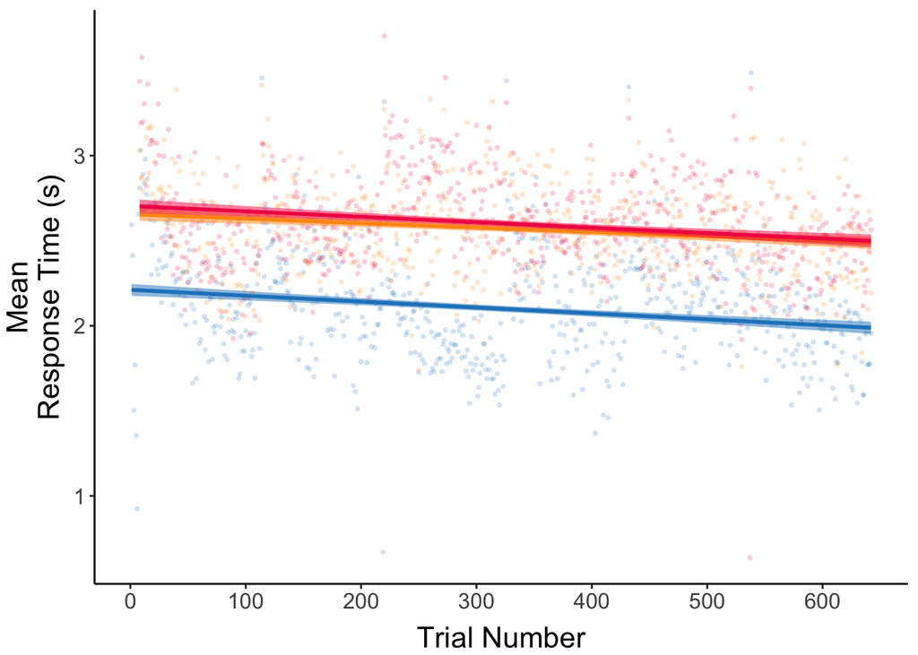

```r
# average RT across each condition per participant
RTs.overTime <- data %>%
  group_by(PID, condType, RawTrialOrder) %>%
  summarize(clipRT = mean(RT))

# average RTs per condition across participants
RTs.participant <- RTs.overTime %>%
  group_by(condType, RawTrialOrder) %>%
  summarize(participantMeanRT = mean(clipRT))

# Note: Summarize gives a friendly warning for the above code notifying me that I am grouping by PID, condType, and RawTrialOrder in the first pipe and by condType and RawTrialOrder in the second pipe. This is merely a warning and does not affect the summarized data.

ggplot(RTs.overTime,
       aes(x = RawTrialOrder, y = clipRT, fill = condType,
           color = condType, group = condType)) +
  # geom_point(alpha = 0.05, shape = 20, size = 2, stroke = 0) +
  # plot average RTs across participants per trial
  geom_point(data = RTs.participant, aes(x = RawTrialOrder, y = participantMeanRT,
                                         fill = condType, color = condType, group = condType),
             alpha = 0.2, shape = 20, size = 2, stroke = 0) +
  geom_smooth(method = "lm", alpha = 0.5, size = 1) +
  scale_x_continuous(breaks = scales::pretty_breaks(n = 6)) +
  scale_color_manual(values = colors, name = "Group") +
  scale_fill_manual(values = colors, name = "Group") +
  xlab("Trial Number") +
  ylab("Mean\nResponse Time (s)") +
  theme_classic() +
  theme(legend.position = "none",
        panel.background = element_blank(),
        axis.title.x = element_text(vjust = -0.4, size = 16),
        axis.title.y = element_text(vjust = 1.5, size = 16),
        axis.text = element_text(size = 12),
        legend.text = element_text(size = 10),
        legend.title = element_text(size = 12))
```

```r
RT.conditionTime <- last_plot()
```

## Compare interaction model

```r
# run multilevel model
modelW <- lmer(RT ~ condType * RawTrialOrder + (1|PID), data = data)

# run main effect model (null)
null.modelW <- lmer(RT ~ condType + RawTrialOrder + (1|PID), data = data)

anova(modelW, null.modelW)
```

|  | npar | AIC | BIC | logLik | deviance | Chisq | Df | Pr(>Chisq) |
| --- | --- | --- | --- | --- | --- | --- | --- | --- |
| null.modelW | 6 | 95305.90821 | 95356.64123 | -47646.95410 | 95293.90821 | NA | NA | NA |
| modelW | 8 | 95284.62648 | 95352.27050 | -47634.31324 | 95268.62648 | 25.28173045 | 2 | 3.236994683e-06 |

## Standardized Betas

```r
# standardize trial number
data$RawTrialOrder.z <- as.numeric(scale(data$RawTrialOrder))

# set win as the reference
data$condType <- as.factor(data$condType)
data <- within(data, condType <- relevel(condType, ref = "Win"))

# run multilevel model
modelW <- lmer(RT.z ~ condType * RawTrialOrder.z + (1|PID), data = data)
# summarize model
summary(modelW)
```

```
## Linear mixed model fit by REML. t-tests use Satterthwaite's method [
## lmerModLmerTest]
## Formula: RT.z ~ condType * RawTrialOrder.z + (1 | PID)
##    Data: data
##
## REML criterion at convergence: 92793.5
##
## Scaled residuals:
##        Min         1Q     Median         3Q        Max
## -2.8166412 -0.7481028 -0.1184501  0.6673512  3.8486041
##
## Random effects:
##  Groups   Name        Variance  Std.Dev.
##  PID      (Intercept) 0.1118841 0.3344909
##  Residual             0.8397440 0.9163755
## Number of obs: 34735, groups:  PID, 57
##
## Fixed effects:
##                                     Estimate    Std. Error            df
## (Intercept)                    -3.082689e-01  4.510832e-02  5.870159e+01
## condTypeFriend                  4.561508e-01  1.203595e-02  3.467334e+04
## condTypeRival                   4.858615e-01  1.204154e-02  3.467343e+04
## RawTrialOrder.z                -7.617706e-02  8.849489e-03  3.472725e+04
## condTypeFriend:RawTrialOrder.z  6.060089e-02  1.331306e-02  3.466927e+04
## condTypeRival:RawTrialOrder.z   3.152110e-03  1.319808e-02  3.472000e+04
##                                 t value   Pr(>|t|)
## (Intercept)                    -6.83397 5.2804e-09 ***
## condTypeFriend                 37.89903 < 2.22e-16 ***
## condTypeRival                  40.34879 < 2.22e-16 ***
## RawTrialOrder.z                -8.60807 < 2.22e-16 ***
## condTypeFriend:RawTrialOrder.z  4.55199 5.3322e-06 ***
## condTypeRival:RawTrialOrder.z   0.23883    0.81124
## ---
## Signif. codes:  0 '***' 0.001 '**' 0.01 '*' 0.05 '.' 0.1 ' ' 1
##
## Correlation of Fixed Effects:
##             (Intr) cndTyF cndTyR RwTrO. cTF:RT
## condTypFrnd -0.132
## condTypeRvl -0.132  0.496
## RwTrlOrdr.z  0.008 -0.030 -0.029
## cndTyF:RTO. -0.006  0.027  0.023 -0.725
## cndTyR:RTO. -0.005  0.020 -0.007 -0.698  0.468
```

```r
# get confidence intervals
confint(modelW)
```

```
##                                         2.5 %         97.5 %
## .sig01                          0.27809794292  0.40390092316
## .sigma                          0.90953210726  0.92317144737
## (Intercept)                    -0.39734177902 -0.21919240765
## condTypeFriend                  0.43256160827  0.47973957598
## condTypeRival                   0.46226110082  0.50946097522
## RawTrialOrder.z                -0.09351696409 -0.05882934230
## condTypeFriend:RawTrialOrder.z  0.03449613705  0.08668111104
## condTypeRival:RawTrialOrder.z  -0.02271316807  0.02901904176
```

```r
# get simple slopes
simple_slopes(modelW)
```

|  | condType | RawTrialOrder.z | Test Estimate | Std. Error | df | t value | Pr(>\|t\|) |
| --- | --- | --- | --- | --- | --- | --- | --- |
| 1 | Win | sstest | -0.07617705572 | 0.008849488965 | 34727.25161 | -8.608073983 | 7.737147625e-18 |
| 2 | Friend | sstest | -0.01557616371 | 0.009203618277 | 34713.89092 | -1.692395669 | 9.057953160e-02 |
| 3 | Rival | sstest | -0.07302494524 | 0.009454079331 | 34728.46868 | -7.724173099 | 1.155989974e-14 |
| 4 | sstest (Friend) | -1 | 0.39554990654 | 0.017705500932 | 34728.50656 | 22.340509204 | 8.884581905e-110 |
| 5 | sstest (Rival) | -1 | 0.48270943456 | 0.017930937989 | 34725.69260 | 26.920478719 | 5.322508245e-158 |
| 6 | sstest (Friend) | 0 | 0.45615079868 | 0.012035950734 | 34673.33983 | 37.899025076 | 5.278149301e-308 |
| 7 | sstest (Rival) | 0 | 0.48586154503 | 0.012041538656 | 34673.42835 | 40.348792536 | 0.000000000e+00 |
| 8 | sstest (Friend) | 1 | 0.51675169066 | 0.018185670484 | 34727.82539 | 28.415322444 | 1.344989666e-175 |
| 9 | sstest (Rival) | 1 | 0.48901365551 | 0.017800492894 | 34726.16663 | 27.471916560 | 2.188865629e-164 |

```r
# run main effect model (null)
null.modelW <- lmer(RT.z ~ condType + RawTrialOrder.z + (1|PID), data = data)
anova(modelW, null.modelW)
```

|  | npar | AIC | BIC | logLik | deviance | Chisq | Df | Pr(>Chisq) |
| --- | --- | --- | --- | --- | --- | --- | --- | --- |
| null.modelW | 6 | 92789.46623 | 92840.19925 | -46388.73312 | 92777.46623 | NA | NA | NA |
| modelW | 8 | 92768.18450 | 92835.82853 | -46376.09225 | 92752.18450 | 25.28173045 | 2 | 3.236994683e-06 |

# 3. Identify ‘average’ friendship and rivalry networks

Identify the “average” network for friendship and rivalry and assume that it is the “correct” network.

To calculate network accuracy, we first calculate the mean % time chosen that each contestant pair (dyad) is chosen as friends or rivals (averaged across all participants). We then calculate the mean % time chosen at the participant level (averaged across each participant’s responses). Next, we see which dyads the group chose as friends or rivals >50% of the time and <50% of the time. We also see which dyads each participant chosen as friends or rivals >50% of the time and <50% of the time. Then, we see how often each participant agrees with the group.

Group >50%, Participant >50% = agreement Group >50%, Participant <50% = disagreement Group <50%, Participant <50% = agreement Group <50%, Participant >50% = disagreement

Finally, we calculate accuracy (measured as the % time each participant agreed with the group).

For stats, we run a one-tailed t-test to see if participant-level accuracy is significantly greater than chance (50%). If it is, we can infer that participants are learning the network!

```r
# reformat choice data
unique.targets <- unique(data$Target)
unique.choices <- unique(data$choice)
formatted.choices <- data.frame()

# calculate % time chosen
for (x in 1:length(unique(data$Target))) {
  all.choices <- data.frame()
  # subset to one target only
  test <- subset(data, data$Target == unique.targets[x])
  # loop through possible choices
  for (y in 1:length(unique(data$choice))) {
    # how many times was each person an option?
    choices <- subset(test, c(test$LeftPersonImg == unique.choices[y] | test$RightPersonImg == unique.choices[y]))
    # group by sub ID & clip #, count the number of times someone appears as a choice vs % time chosen
    choices <- choices %>%
      group_by(PID,Target,condType,ClipNumber) %>%
        mutate(n = str_count(choice, unique.choices[y])) %>%
          summarize(option = length(Target),
                    selected = sum(n))
    # add in choice name
    choices$ChoiceOption <- unique.choices[y]
    # calculate percent of time chosen
    choices <- choices %>%
      group_by(PID,ClipNumber,condType,Target,ChoiceOption) %>%
        summarize(percent.chosen = selected/option)
    # save choices into new data frame
    all.choices <- rbind(all.choices, choices)
  }
  # save all targets into new data frame
  formatted.choices <- rbind(formatted.choices, all.choices)
}

# This loop gives the friendly warning:
# `summarise()` has grouped output by 'PID', 'Target', 'condType', 'ClipNumber', 'ChoiceOption'. You can override using the `.groups` argument.
# This is not an issue, it is just telling me which columns I've grouped by before summarizing.

# remove data frames that are no longer needed
rm(all.choices)
rm(choices)
rm(test)
```

```r
# add dyad info
formatted.choices <- data.frame(formatted.choices, stringsAsFactors = F) %>%
  mutate(dyad = paste0(pmin(Target,ChoiceOption), pmax(Target,ChoiceOption), sep=""))

# calculate average percent chosen across participants across clips
# group.chosen shows the average % time chosen each dyad is chosen as friends or rivals or winners by the group
group.chosen <- formatted.choices %>%
  group_by(dyad, condType) %>%
  summarize(groupTimeChosen = mean(percent.chosen))

# calculate participant averages (collapse across 2x repeated block types)
# participant.chosen shows the average % time each dyad is chosen as friends, rivals, or winners by each PID
participant.chosen <- formatted.choices %>%
  group_by(PID, dyad, condType) %>%
  summarize(participantTimeChosen = mean(percent.chosen))

# join group.chosen and participant.chosen
chosen <- merge(group.chosen, participant.chosen, by = c("dyad","condType"))

# only include friend and rival
chosen <- subset(chosen, condType != "Win")

# add column to mark where the group chose a dyad greater than 50% of the time
chosen$groupChosen <- ifelse(chosen$groupTimeChosen >= .5, 1, 0)

# add column to mark where each participant chose a dyad greater than 50% of the time
chosen$participantChosen <- ifelse(chosen$participantTimeChosen >= .5, 1, 0)

# add column to mark where group and participant agree
chosen$agreement <- ifelse(chosen$groupChosen == chosen$participantChosen, 1, 0)

# get overall accuracy measure per participant
chosen <- chosen %>%
  group_by(PID, condType) %>%
  mutate(PID.OverallAccuracy = mean(agreement))

accuracy <- chosen %>%
  group_by(PID, condType) %>%
  summarize(PID.OverallAccuracy = mean(agreement))

friend.accuracy <- subset(accuracy, condType == "Friend")
rival.accuracy <- subset(accuracy, condType == "Rival")

# t test to see if PID accuracy is significantly greater than chance (50%)
t.test(friend.accuracy$PID.OverallAccuracy, alternative = "greater", mu = 0.5)
```

```
##
##  One Sample t-test
##
## data:  friend.accuracy$PID.OverallAccuracy
## t = 17.082019, df = 56, p-value < 2.2204e-16
## alternative hypothesis: true mean is greater than 0.5
## 95 percent confidence interval:
##  0.7264642119          Inf
## sample estimates:
##    mean of x
## 0.7510442774
```

```r
t.test(rival.accuracy$PID.OverallAccuracy, alternative = "greater", mu = 0.5)
```

```
##
##  One Sample t-test
##
## data:  rival.accuracy$PID.OverallAccuracy
## t = 15.682707, df = 56, p-value < 2.2204e-16
## alternative hypothesis: true mean is greater than 0.5
## 95 percent confidence interval:
##  0.6981496028          Inf
## sample estimates:
##    mean of x
## 0.7218045113
```

```r
# Using summarize in this chunk gives the following messages:
# `summarise()` has grouped output by 'dyad'. You can override using the `.groups` argument.
# `summarise()` has grouped output by 'PID', 'dyad'. You can override using the `.groups` argument.
# `summarise()` has grouped output by 'PID'. You can override using the `.groups` argument.
# This is not an issue, it is just telling me which columns I've grouped by before summarizing.
```

## Plot!

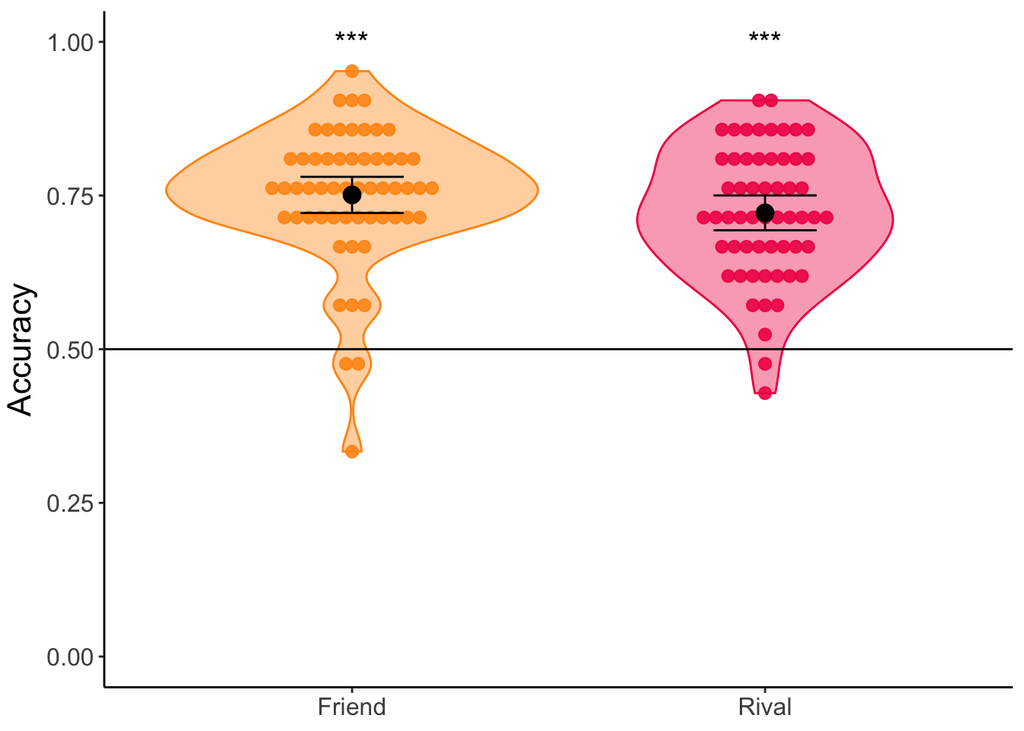

```r
# get summary measures
PIDaccuracy <- summarySE(accuracy, measurevar = "PID.OverallAccuracy", groupvars = "condType")

# use accuracy data frame to plot
ggplot(accuracy, aes(x = condType, y = PID.OverallAccuracy, color = condType, fill = condType)) +
  geom_dotplot(binaxis = "y", stackdir = "center", dotsize = 2, binwidth = 0.01, alpha = 0.9) +
  geom_violin(alpha = 0.4) +
  scale_fill_manual(values = plot.colors) +
  scale_color_manual(values = plot.colors) +
  # add 95% confidence intervals
  geom_errorbar(data = PIDaccuracy, aes(ymin = PID.OverallAccuracy-ci, ymax = PID.OverallAccuracy+ci),
                width = 0.25, position = "dodge", color = "black") +
  # add point for mean of each valence category
  geom_point(data = PIDaccuracy,
             aes(x = condType, y = PID.OverallAccuracy), color = "black", shape = 16,
             size = 4) +
  geom_hline(yintercept = 0.5) +
  # add significance stars
  ggplot2::annotate("text", x = 1, y = 1, label = "***", size = 5) +
  ggplot2::annotate("text", x = 2, y = 1, label = "***", size = 5) +
  ylim(0,1) +
  xlab(NULL) +
  ylab("Accuracy") +
  theme_classic() +
  theme(legend.position = "none",
        panel.background = element_blank(),
        axis.title.x = element_text(vjust = -0.4, size = 16),
        axis.title.y = element_text(vjust = 1.5, size = 16),
        axis.text = element_text(size = 12),
        legend.text = element_text(size = 10),
        legend.title = element_text(size = 12))
```

```r
accuracy.plot <- last_plot()
```

# Plot all three!

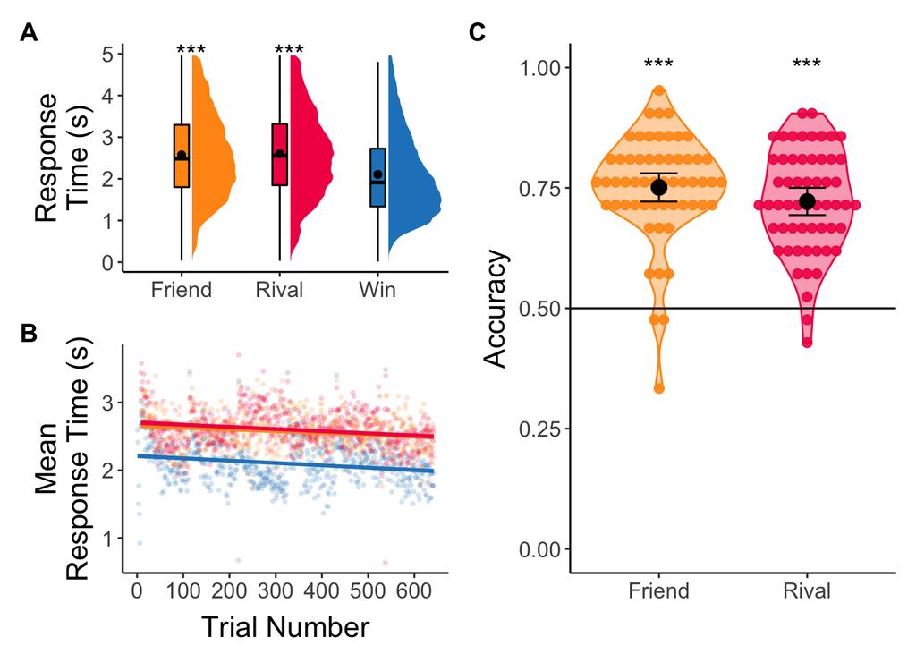

```r
# patchwork plot and save
patchwork <- (RT.condition / RT.conditionTime) | accuracy.plot
patchwork + plot_annotation(tag_levels = "A") & theme(plot.tag = element_text(size = 14, face = "bold"))
```

```r
ggsave(filename = "Study1-multiplot.pdf",
       path = "/Volumes/GoogleDrive/My Drive/SANLab/Manuscripts/Survivor+Language/MarkdownFigures",
       width = 10, height = 5,
       units = c("in"))

ggsave(filename = "Study1-multiplot.jpeg",
       path = "/Volumes/GoogleDrive/My Drive/SANLab/Manuscripts/Survivor+Language/MarkdownFigures",
       width = 10, height = 5,
       units = c("in"))
```

# 4. Network Graph

```r
# load preferred color palette from met brewer
pp <- met.brewer(name = "Hiroshige")
colors <- c("#2185c5ff","#ff9715ff","#f20253ff","#7ecefdff","#1c3aa9ff")

# load data
dat_csv <- read.csv("./Paper-Analysis/data/dat_survivor.csv")

capFirst <- function(s) {paste(toupper(substring(s, 1, 1)), substring(s, 2), sep = "")}
dat_csv$Target <- capFirst(dat_csv$Target)
dat_csv$choice <- capFirst(dat_csv$choice)
dat_csv$Target[dat_csv$Target == "Shiiann"] <- "Shii Ann"
dat_csv$choice[dat_csv$choice == "Shiiann"] <- "Shii Ann"
```

## Friend Network

```r
set.seed(1)
# select friend condition rows
friend <- dat_csv %>%
  filter(condType == "Friend")

# rename to reflect target (whom they were making the decision about)...
targets <- friend %>%
  distinct(Target) %>%
  dplyr::rename(label = Target)
# and choice (whom they chose as that person's friend)
choices <- friend %>%
  distinct(choice) %>%
  dplyr::rename(label = choice)

# create nodes and edges of network
nodes <- full_join(targets, choices) %>% rowid_to_column("id")
# create choices
per_choice <- friend %>%
  group_by(Target, choice) %>%
  dplyr::summarise(weight = n()) %>%
  ungroup()
# create edges of network
edges <- per_choice %>%
  left_join(nodes, by = c("Target" = "label")) %>%
  dplyr::rename(from = id) %>%
  left_join(nodes, by = c("choice" = "label")) %>%
  dplyr::rename(to = id)
edges <- dplyr::select(edges, from, to, weight)

# label nodes
nodes$label <- as.character(nodes$label)

# create network figure!
friend_igraph <-
  graph_from_data_frame(d = edges,
                        vertices = nodes,
                        directed = TRUE)
Eig <- eigen_centrality(friend_igraph)$vector
page_rank <- page_rank(friend_igraph)$vector

nodes_PR <- cbind(nodes, data.frame(page_rank))
coords <- layout_nicely(friend_igraph)

# save
jpeg(file="/Volumes/GoogleDrive/My Drive/SANLab/Manuscripts/Survivor+Language/MarkdownFigures/Study1_friend_network.jpeg",
     width = 2100, height = 1500, units = "px")
pdf(file="/Volumes/GoogleDrive/My Drive/SANLab/Manuscripts/Survivor+Language/MarkdownFigures/Study1_friend_network.pdf",
     width = 10, height = 8 )

# save page ranks for later table
friend.pagerank <- page_rank
friend.nodes <- nodes$label
friend.pagerank <- data.frame(friend.nodes,friend.pagerank)
names(friend.pagerank)[1] <- "Names"

## update denominator under edge.width to reflect # of participants
plot(
  friend_igraph,
  edge.arrow.size = 1,
  edge.curved = 0.3,
  edge.width = ((E(friend_igraph)$weight/25))/3,
  vertex.color = colors[2],
  vertex.size = page_rank*450,
  vertex.frame.color = colors[2],
  vertex.label.color = "black",
  vertex.label.cex = 1,
  vertex.label.family = "sans",
  vertex.label.font = 2,
  layout = coords)
```

## Rival Network

```r
set.seed(1)
# select friend condition rows
rival <- dat_csv %>%
  filter(condType == "Rival")

# rename to reflect target (whom they were making the decision about)...
targets <- rival %>%
  distinct(Target) %>%
  dplyr::rename(label = Target)
# and choice (whom they chose as that person's rival)
choices <- rival %>%
  distinct(choice) %>%
  dplyr::rename(label = choice)

# create nodes and edges of network
nodes <- full_join(targets, choices) %>% rowid_to_column("id")
# create choices
per_choice <- rival %>%
  group_by(Target, choice) %>%
  dplyr::summarise(weight = n()) %>%
  ungroup()
# create edges of network
edges <- per_choice %>%
  left_join(nodes, by = c("Target" = "label")) %>%
  dplyr::rename(from = id) %>%
  left_join(nodes, by = c("choice" = "label")) %>%
  dplyr::rename(to = id)
edges <- dplyr::select(edges, from, to, weight)

# label nodes
nodes$label <- as.character(nodes$label)

# create network figure!
friend_igraph <-
  graph_from_data_frame(d = edges,
                        vertices = nodes,
                        directed = TRUE)
Eig <- eigen_centrality(friend_igraph)$vector
page_rank <- page_rank(friend_igraph)$vector

nodes_PR <- cbind(nodes, data.frame(page_rank))
coords <- layout_nicely(friend_igraph)

# save
jpeg(file="/Volumes/GoogleDrive/My Drive/SANLab/Manuscripts/Survivor+Language/MarkdownFigures/Study1_rival_network.jpeg",
     width = 2100, height = 1500, units = "px")
pdf(file="/Volumes/GoogleDrive/My Drive/SANLab/Manuscripts/Survivor+Language/MarkdownFigures/Study1_rival_network.pdf",
     width = 10, height = 8 )

# save page ranks for later table
rival.pagerank <- page_rank
rival.nodes <- nodes$label
rival.pagerank <- data.frame(rival.nodes, rival.pagerank)
names(rival.pagerank)[1] <- "Names"

## update denominator under edge.width to reflect # of participants
plot(
  friend_igraph,
  edge.arrow.size = 1,
  edge.curved = 0.3,
  edge.width = ((E(friend_igraph)$weight/25))/3,
  vertex.color = colors[3],
  vertex.size = page_rank*450,
  vertex.frame.color = colors[3],
  vertex.label.color = "black",
  vertex.label.cex = 1,
  vertex.label.family = "sans",
  vertex.label.font = 2,
  layout = coords)
```

# 5. Avg % time chosen friends/rivals

```r
# set up data frame with names and order voted off
Names <- c("Amber", "Rob", "Jenna", "Rupert", "Tom", "Shii Ann", "Alicia")
order <- c("Winner", "6th", "5th", "4th", "3rd", "2nd", "1st")
avg.time <- data.frame(Names, order)
# merge with pageranks
avg.time <- merge(avg.time, friend.pagerank, by = "Names")
avg.time <- merge(avg.time, rival.pagerank, by = "Names")

# read in all formatted choice data
df.clean <- read.csv("./Paper-Analysis/data/df-clean.csv")
# calculate avg time each choice is chosen as friends or rivals
test <- df.clean %>%
  group_by(ChoiceOption, condType) %>%
  summarize(avg.PercentChosen = mean(percent.chosen))

# friends
friend <- subset(test, condType == "Friend")
names(friend)[3] <- "Average % Time Chosen as Friends"
names(friend)[1] <- "Names"
friend <- friend[,-2]
friend$Names[friend$Names == "ShiiAnn"] <- "Shii Ann"
# rivals
rival <- subset(test, condType == "Rival")
names(rival)[3] <- "Average % Time Chosen as Rivals"
names(rival)[1] <- "Names"
rival <- rival[,-2]
rival$Names[rival$Names == "ShiiAnn"] <- "Shii Ann"
# win
win <- subset(test, condType == "Win")
names(win)[3] <- "Average % Time Chosen as Winner"
names(win)[1] <- "Names"
win$Names[win$Names == "ShiiAnn"] <- "Shii Ann"
win <- win[,-2]

# merge!
avg.time <- merge(avg.time, friend, by = "Names")
avg.time <- merge(avg.time, rival, by = "Names")
avg.time <- merge(avg.time, win, by = "Names")

avg.time$order <- factor(avg.time$order, levels = c('Winner', '6th', '5th', '4th', '3rd', '2nd', '1st'))

summary <- avg.time[order(avg.time$order),]

names(summary)[2] <- "Order Voted Off"

# multiply % columns by 100
summary$`Average % Time Chosen as Friends` <- summary$`Average % Time Chosen as Friends`*100
summary$`Average % Time Chosen as Rivals` <- summary$`Average % Time Chosen as Rivals`*100
summary$`Average % Time Chosen as Winner` <- summary$`Average % Time Chosen as Winner`*100

summary.table <- reactable(summary,
            outlined = T, striped = T,
            style = list(fontFamily = "Arial", fontSize = "12px"),
            compact = T,
            resizable = T,
            wrap = T,
            fullWidth = F,
            columns = list(
              `Average % Time Chosen as Rivals` = colDef(name = "Average Time Chosen as Rivals (%)",
                                                         align = "center",
                                                         format = colFormat(digits = 1)),
              `Average % Time Chosen as Friends` = colDef(name = "Average Time Chosen as Friends (%)",
                                                          align = "center",
                                                          format = colFormat(digits = 1)),
              `Average % Time Chosen as Winner` = colDef(name = "Average Time Chosen as Winner (%)",
                                                         align = "center",
                                                         format = colFormat(digits = 1)),
              `Order Voted Off` = colDef(name = "Order Voted Off",
                                         align = "center"),
              Names = colDef(name = "Names",
                             align = "center"),
              friend.pagerank = colDef(name = "Friend PageRank",
                                        align = "center",
                                        format = colFormat(digits = 3)),
              rival.pagerank = colDef(name = "Rival PageRank",
                                      align = "center",
                                      format = colFormat(digits = 3))))
summary.table
```

| Names | Order Voted Off | Friend PageRank | Rival PageRank | Average Time Chosen as Friends (%) | Average Time Chosen as Rivals (%) | Average Time Chosen as Winner (%) |
| --- | --- | --- | --- | --- | --- | --- |
| Amber | Winner | 0.172031353806812 | 0.110665961398728 | 62.0638401559454 | 35.688140556369 | 60.4946393762183 |
| Rob | 6th | 0.174493420968889 | 0.150078640015006 | 61.5618908382066 | 51.4887914230019 | 78.0994152046784 |
| Jenna | 5th | 0.161668258316603 | 0.130305100726478 | 56.0428849902534 | 43.3357699805068 | 49.7904483430799 |
| Rupert | 4th | 0.168438029235717 | 0.135057230511356 | 61.6203703703704 | 46.1908247925818 | 68.8084795321637 |
| Tom | 3rd | 0.136091706548011 | 0.124513694981369 | 49.083820662768 | 42.7997076023392 | 29.7612085769981 |
| Shii Ann | 2nd | 0.0763977514833769 | 0.186465380507341 | 21.5716374269006 | 70.8771929824561 | 31.4717348927875 |
| Alicia | 1st | 0.11087947964059 | 0.162913991859722 | 36.8810916179337 | 59.4883040935673 | 31.5107212475634 |

```r
save_reactable(summary.table, "/Volumes/GoogleDrive/My Drive/SANLab/Manuscripts/Survivor+Language/MarkdownFigures/Study1_summary_table.png")

library(webshot2)
library(htmlwidgets)

html_file <- "/Volumes/GoogleDrive/My Drive/SANLab/Manuscripts/Survivor+Language/MarkdownFigures/summary_table.html"
img_file <- "/Volumes/GoogleDrive/My Drive/SANLab/Manuscripts/Survivor+Language/MarkdownFigures/Study1_summary_table.pdf"

saveWidget(widget = summary.table, file = html_file, selfcontained = TRUE)
webshot(url = html_file, file = img_file, delay = 0.1, vwidth = 1245)
```

[figure not shown]